# **Case Overview**

Customer churn is a major challenge for businesses that rely on recurring user engagement, particularly in the online gambling industry. Retaining customers is far more cost-effective than acquiring new ones, making churn prediction a valuable tool for customer relationship management (CRM) teams.

This project aims to build a **machine learning model to predict customer churn** for a leading online casino operator. By identifying players likely to become inactive, the CRM team can proactively engage them with personalized incentives, reducing churn rates and increasing customer lifetime value.

## **Objective**

The goal is to **develop a predictive model that classifies players as likely to churn or not** based on their historical gaming and transaction behavior.

## **Dataset Overview**

The dataset includes **12,500 customers** who made their first deposit within a **2.5-year period**, with daily aggregated transaction and engagement data. Key features include:

- **Player activity**: Number of logins, bets placed, and deposits/withdrawals.
- **Financial metrics**: Total deposit/withdrawal amounts and net gaming revenue (NGR).
- **Demographics**: Player birth year.

## **Key Takeaways**

This project demonstrates **end-to-end data science skills**, from defining a business problem to implementing a data-driven solution. It highlights best practices in **EDA, feature engineering, machine learning, and model evaluation**.

# EDA

```python
import pandas as pd
import numpy as np
import matplotlib.pyplot as plt
import seaborn as sns

# Load dataset
df = pd.read_csv("data.csv", parse_dates=["date"])

# Convert date column to datetime format
df['date'] = pd.to_datetime(df['date'])

# Convert birth year into age.
latest_year = df['date'].dt.year.max()
df['age'] = latest_year - df['birth_year']
df.drop(columns=['birth_year'], inplace=True)

# Convert the player_key column to string
df['player_key'] = df['player_key'].astype(str)

# Sort by player and date to ensure chronological order
df = df.sort_values(['player_key', 'date'])

df.head(10)
```

|  | player_key | date | turnover_sum | turnover_num | NGR_sum | deposit_sum | deposit_num | withdrawal_sum | withdrawal_num | login_num | age |
| --- | --- | --- | --- | --- | --- | --- | --- | --- | --- | --- | --- |
| 222075 | -100156789188932904 | 2020-07-12 | 7.99 | 10 | 6.47 | 7 | 1 | 0 | 0 | 1 | 46 |
| 222069 | -100156789188932904 | 2020-07-28 | 10.13 | 49 | -2.33 | 4 | 1 | 0 | 0 | 1 | 46 |
| 55426 | -100156789188932904 | 2020-08-03 | 4.36 | 46 | 0.24 | 0 | 0 | 0 | 0 | 1 | 46 |
| 55403 | -100156789188932904 | 2020-08-07 | 12.06 | 32 | -5.53 | 0 | 0 | 0 | 0 | 1 | 46 |
| 55378 | -100156789188932904 | 2020-08-13 | 33.40 | 189 | 7.21 | 0 | 0 | 0 | 0 | 1 | 46 |
| 55394 | -100156789188932904 | 2020-08-16 | 0.35 | 4 | -0.47 | 0 | 0 | 0 | 0 | 1 | 46 |
| 55415 | -100156789188932904 | 2020-08-20 | 10.55 | 99 | 5.32 | 0 | 0 | 0 | 0 | 1 | 46 |
| 55402 | -100156789188932904 | 2020-08-21 | 0.00 | 0 | 0.00 | 0 | 0 | 0 | 0 | 1 | 46 |
| 55406 | -100156789188932904 | 2020-09-01 | 0.00 | 0 | 0.00 | 0 | 0 | 0 | 0 | 1 | 46 |
| 222084 | -100156789188932904 | 2020-09-03 | 12.67 | 55 | 8.73 | 9 | 1 | 0 | 0 | 3 | 46 |

```python
# Look at single player data.
pk = np.random.choice(df['player_key'].unique())
player_data = df[df['player_key'] == pk].sort_values('date')
player_data
```

|  | player_key | date | turnover_sum | turnover_num | NGR_sum | deposit_sum | deposit_num | withdrawal_sum | withdrawal_num | login_num | age |
| --- | --- | --- | --- | --- | --- | --- | --- | --- | --- | --- | --- |
| 195795 | -2290450308142927403 | 2020-12-30 | 300.24 | 334 | -27.59 | 45 | 1 | 0 | 0 | 1 | 23 |
| 195777 | -2290450308142927403 | 2020-12-31 | 484.99 | 354 | 10.35 | 45 | 1 | 89 | 1 | 0 | 23 |
| 195794 | -2290450308142927403 | 2021-01-22 | 1313.36 | 365 | 33.97 | 134 | 1 | 90 | 1 | 1 | 23 |
| 43484 | -2290450308142927403 | 2021-03-25 | 0.00 | 0 | 0.00 | 0 | 0 | 0 | 0 | 1 | 23 |
| 195786 | -2290450308142927403 | 2021-08-21 | 160.58 | 286 | 34.83 | 44 | 1 | 0 | 0 | 1 | 23 |
| 43483 | -2290450308142927403 | 2021-08-23 | 0.05 | 1 | -5.76 | 0 | 0 | 0 | 0 | 0 | 23 |
| 195788 | -2290450308142927403 | 2021-10-26 | 198.40 | 131 | 4.43 | 45 | 1 | 0 | 0 | 1 | 23 |
| 43489 | -2290450308142927403 | 2021-10-27 | 86.94 | 104 | 38.88 | 0 | 0 | 0 | 0 | 0 | 23 |
| 43486 | -2290450308142927403 | 2021-11-06 | 0.00 | 0 | 0.00 | 0 | 0 | 0 | 0 | 1 | 23 |
| 195774 | -2290450308142927403 | 2021-12-05 | 194.38 | 443 | 50.79 | 65 | 1 | 0 | 0 | 1 | 23 |
| 43488 | -2290450308142927403 | 2021-12-07 | 0.05 | 1 | -4.03 | 0 | 0 | 0 | 0 | 0 | 23 |
| 195789 | -2290450308142927403 | 2022-01-28 | 42.26 | 129 | 21.87 | 22 | 1 | 0 | 0 | 1 | 23 |
| 195791 | -2290450308142927403 | 2022-03-04 | 94.64 | 176 | 36.24 | 42 | 1 | 0 | 0 | 1 | 23 |
| 195784 | -2290450308142927403 | 2022-04-29 | 174.50 | 354 | 10.74 | 22 | 1 | 0 | 0 | 2 | 23 |
| 195793 | -2290450308142927403 | 2022-05-09 | 104.91 | 317 | 34.25 | 43 | 1 | 0 | 0 | 1 | 23 |
| 195782 | -2290450308142927403 | 2022-05-10 | 23.40 | 54 | 19.26 | 21 | 1 | 0 | 0 | 1 | 23 |
| 195775 | -2290450308142927403 | 2022-05-27 | 76.84 | 118 | 39.19 | 43 | 1 | 0 | 0 | 1 | 23 |
| 195790 | -2290450308142927403 | 2022-06-07 | 35.82 | 93 | 5.23 | 9 | 1 | 0 | 0 | 1 | 23 |
| 195772 | -2290450308142927403 | 2022-06-24 | 32.00 | 135 | 16.12 | 21 | 1 | 0 | 0 | 1 | 23 |
| 195785 | -2290450308142927403 | 2022-07-04 | 33.77 | 204 | 13.79 | 21 | 1 | 0 | 0 | 1 | 23 |
| 195781 | -2290450308142927403 | 2022-07-09 | 26.88 | 110 | 17.12 | 21 | 1 | 0 | 0 | 1 | 23 |
| 195792 | -2290450308142927403 | 2022-08-08 | 73.57 | 209 | 14.02 | 22 | 1 | 0 | 0 | 1 | 23 |
| 195778 | -2290450308142927403 | 2022-09-13 | 41.98 | 158 | 15.68 | 21 | 1 | 0 | 0 | 1 | 23 |
| 195773 | -2290450308142927403 | 2022-09-18 | 52.03 | 253 | 11.90 | 21 | 1 | 0 | 0 | 1 | 23 |
| 195783 | -2290450308142927403 | 2022-09-26 | 67.53 | 215 | 33.71 | 41 | 1 | 0 | 0 | 1 | 23 |
| 195776 | -2290450308142927403 | 2022-10-25 | 33.98 | 166 | 14.68 | 20 | 1 | 0 | 0 | 1 | 23 |
| 195780 | -2290450308142927403 | 2022-10-29 | 23.75 | 86 | 8.89 | 41 | 1 | 0 | 0 | 1 | 23 |
| 43487 | -2290450308142927403 | 2022-10-30 | 73.54 | 28 | 14.59 | 0 | 0 | 0 | 0 | 0 | 23 |
| 43490 | -2290450308142927403 | 2022-12-09 | 30.81 | 83 | 11.23 | 0 | 0 | 0 | 0 | 1 | 23 |
| 195787 | -2290450308142927403 | 2022-12-31 | 111.50 | 136 | 7.12 | 40 | 1 | 28 | 1 | 1 | 23 |
| 195779 | -2290450308142927403 | 2023-01-05 | 20.06 | 88 | 5.18 | 20 | 1 | 12 | 1 | 1 | 23 |
| 43485 | -2290450308142927403 | 2023-03-31 | -0.16 | 0 | -0.16 | 0 | 0 | 0 | 0 | 0 | 23 |

```python
print(df.isnull().sum())
# No missing data.
```

```
player_key        0
date              0
turnover_sum      0
turnover_num      0
NGR_sum           0
deposit_sum       0
deposit_num       0
withdrawal_sum    0
withdrawal_num    0
login_num         0
age               0
dtype: int64
```

```python
df.info()
df.describe(percentiles=[0.01, 0.25, 0.5, 0.75, 0.99])
# Many columns have long tails. Some with extremely high max values.
# Many users do not withdraw funds, suggesting retained balances.
```

```
<class 'pandas.core.frame.DataFrame'>
Int64Index: 416939 entries, 222075 to 235267
Data columns (total 11 columns):
 #   Column          Non-Null Count   Dtype
---  ------          --------------   -----
 0   player_key      416939 non-null  object
 1   date            416939 non-null  datetime64[ns]
 2   turnover_sum    416939 non-null  float64
 3   turnover_num    416939 non-null  int64
 4   NGR_sum         416939 non-null  float64
 5   deposit_sum     416939 non-null  int64
 6   deposit_num     416939 non-null  int64
 7   withdrawal_sum  416939 non-null  int64
 8   withdrawal_num  416939 non-null  int64
 9   login_num       416939 non-null  int64
 10  age             416939 non-null  int64
dtypes: datetime64[ns](1), float64(2), int64(7), object(1)
memory usage: 38.2+ MB
```

|  | turnover_sum | turnover_num | NGR_sum | deposit_sum | deposit_num | withdrawal_sum | withdrawal_num | login_num | age |
| --- | --- | --- | --- | --- | --- | --- | --- | --- | --- |
| count | 416939.000000 | 416939.000000 | 416939.000000 | 416939.000000 | 416939.000000 | 416939.000000 | 416939.000000 | 416939.000000 | 416939.000000 |
| mean | 145.863234 | 124.166593 | 6.704987 | 26.120663 | 1.112981 | 19.035372 | 0.243012 | 1.528358 | 36.955936 |
| std | 973.176321 | 238.528250 | 166.889940 | 70.417036 | 1.269387 | 112.396788 | 0.527907 | 1.228827 | 15.469961 |
| min | -26.820000 | 0.000000 | -62045.020000 | 0.000000 | 0.000000 | 0.000000 | 0.000000 | 0.000000 | 18.000000 |
| 1% | 0.000000 | 0.000000 | -229.678600 | 0.000000 | 0.000000 | 0.000000 | 0.000000 | 0.000000 | 19.000000 |
| 25% | 5.500000 | 4.000000 | 0.000000 | 0.000000 | 0.000000 | 0.000000 | 0.000000 | 1.000000 | 23.000000 |
| 50% | 27.020000 | 35.000000 | 4.420000 | 9.000000 | 1.000000 | 0.000000 | 0.000000 | 1.000000 | 33.000000 |
| 75% | 100.275000 | 134.000000 | 16.300000 | 24.000000 | 1.000000 | 0.000000 | 0.000000 | 2.000000 | 49.000000 |
| 99% | 1758.454600 | 1152.000000 | 212.500000 | 225.620000 | 6.000000 | 342.000000 | 2.000000 | 6.000000 | 75.000000 |
| max | 347559.240000 | 8378.000000 | 44386.840000 | 8423.000000 | 59.000000 | 20686.000000 | 24.000000 | 48.000000 | 95.000000 |

## Now we will look at the numerical columns more closely with some plots.

[figure not shown]

```python
# From our table from df.describe, we know that we have long tails and extremely high max values.
# Lets try capping numerical values between the 1st and 99th percentile.

excluded_columns = ['player_key', 'date']
target_columns = df.columns.difference(excluded_columns)

for col in target_columns:
    min_threshold = df[col].quantile(0.01)
    max_threshold = df[col].quantile(0.99)
    df[col] = np.where(df[col] < min_threshold, min_threshold,
                           np.where(df[col] > max_threshold, max_threshold, df[col]))

df.plot(kind='hist', subplots=True, layout=(4, 4), figsize=(18, 15), bins=50, alpha=0.7)
plt.tight_layout()
plt.show()
```

```python
# Utils.
def retrieve_random_player(dataframe):
    """Fetches session records for a randomly chosen player"""
    pk = np.random.choice(dataframe['player_key'].unique())
    df = dataframe[dataframe['player_key'] == pk].sort_values(by='date')
    return df

def calculate_and_plot_days_since_last(
    activity_column: str,df: pd.DataFrame
):
    """Calculates the days since the last activity (where activity > 0).

    Args:
        df: The input DataFrame with 'player_key', 'date', and activity column.
        activity_column: The name of the column indicating activity (e.g.,
                         'login_num', 'turnover_num').
    """

    # Sort by player and date
    df = df.sort_values(by=["player_key", "date"])

    # Filter out rows where activity is greater than 0
    activity_dates = df[df[activity_column] > 0].copy()

    # Calculate the difference between activity dates
    days_since_column = f"days_since_last_{activity_column.replace('_num', '')}"
    activity_dates[days_since_column] = (
      activity_dates.groupby("player_key")["date"].diff().dt.days
    )

    # Remove outliers in the 'days_since_last_activity' column by capping
    # the values at the 1st and 99th percentile

    lower_bound = activity_dates[days_since_column].quantile(0.01)
    upper_bound = activity_dates[days_since_column].quantile(0.99)
    activity_dates[days_since_column] = np.clip(
        activity_dates[days_since_column], lower_bound, upper_bound
    )



    # Plot the distribution of 'days_since_last_activity'
    plt.figure(figsize=(10, 6))
    sns.histplot(activity_dates[days_since_column], bins=40, kde=True)
    # Add a vertical line at the churn window
    plt.axvline(
        x=30,
        color="red",
        linestyle="--",
        label=f"Churn Window (30 days)",
    )
    plot_title = f"Distribution of Days Since Last {activity_column.replace('_num', '').replace('_sum', '').title()}"
    plt.title(plot_title)
    plt.xlabel(f"Days Since Last {activity_column.replace('_num', '').title()}")
    plt.ylabel("Frequency")
    plt.show()

# Sort by player and date
df = df.sort_values(by=["player_key", "date"])
```

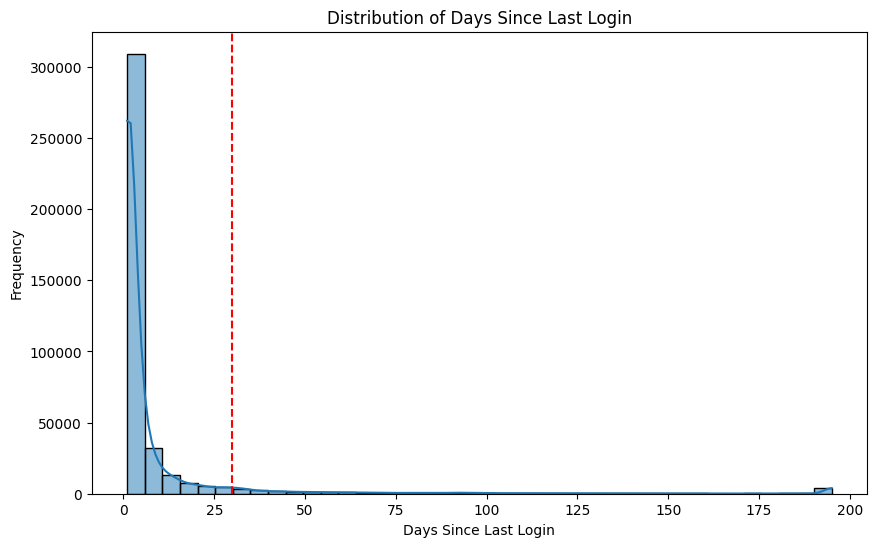

```python
calculate_and_plot_days_since_last("login_num",df)
```

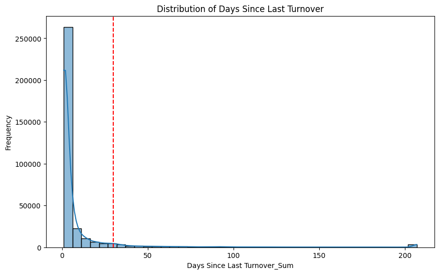

```python
calculate_and_plot_days_since_last("turnover_sum",df)
```

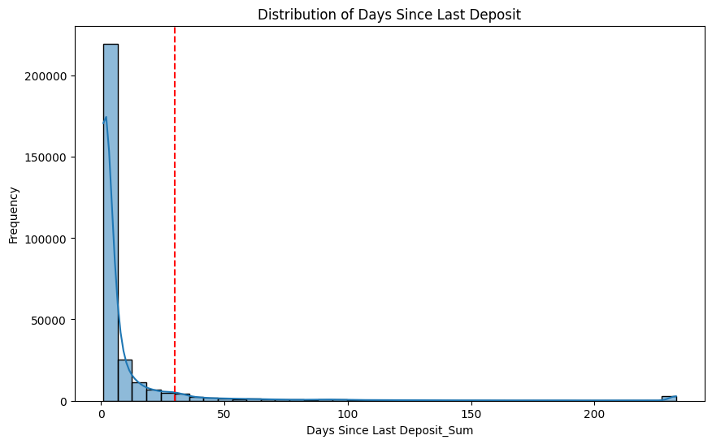

```python
calculate_and_plot_days_since_last("deposit_sum",df)
```

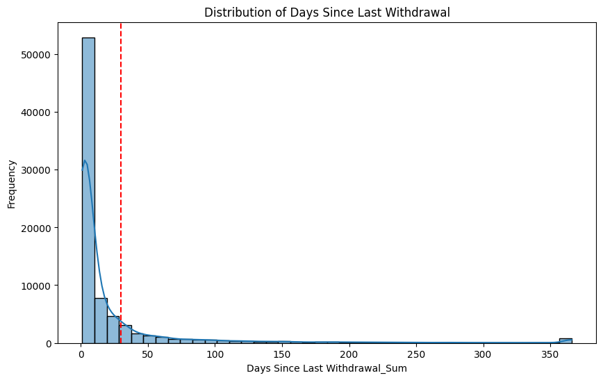

```python
calculate_and_plot_days_since_last("withdrawal_sum",df)
```

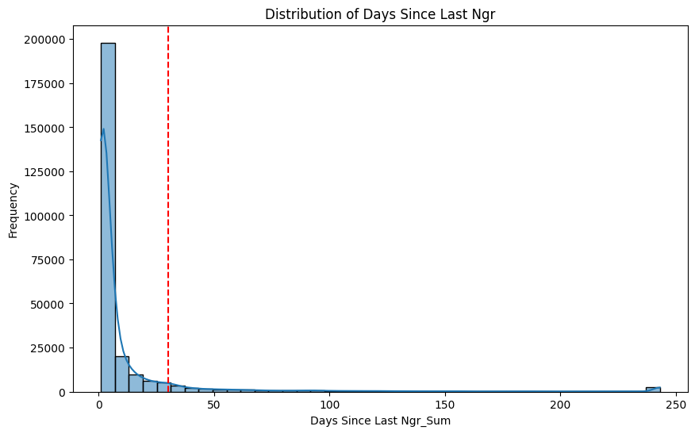

```python
calculate_and_plot_days_since_last("NGR_sum",df)
```

While the case suggested a **30-day timeframe**, the data indicates more **pronounced changes closer to 15 days**. Since our primary objective is to improve retention and protect revenue, I believe focusing on **betting (turnover) – the activity directly generating revenue** – will yield the most actionable insights for churn prediction.

We'll have a very imbalanced classes given that most of our data lie before the 30 day line.

## Feature Engineering

We create the churn label based on our chosen inactivity criteria. Later on, we try to add useful features.

```python
# Create our label called churn. Which we define as a player who has zero turnover_sum for more than 30 days.
# Filter out rows where activity is greater than 0
turnover_dates = df[df["turnover_sum"] > 0].copy()

# Calculate the difference between activity dates
turnover_dates["days_since_last_bet"] = (
  turnover_dates.groupby("player_key")["date"].diff().dt.days
)
# Fill NaN with zero. New players will not have previous bets.
turnover_dates["days_since_last_bet"] = turnover_dates["days_since_last_bet"].fillna(0)
turnover_dates['churned'] = turnover_dates["days_since_last_bet"] > 30 # Churn window
retrieve_random_player(turnover_dates)[["player_key","date","days_since_last_bet","churned"]]
```

|  | player_key | date | days_since_last_bet | churned |
| --- | --- | --- | --- | --- |
| 173719 | -4117809391698564203 | 2022-06-26 | 0.0 | False |
| 173703 | -4117809391698564203 | 2022-06-27 | 1.0 | False |
| 173700 | -4117809391698564203 | 2022-06-28 | 1.0 | False |
| 32032 | -4117809391698564203 | 2022-07-03 | 5.0 | False |
| 173696 | -4117809391698564203 | 2022-07-04 | 1.0 | False |
| 173701 | -4117809391698564203 | 2022-07-05 | 1.0 | False |
| 32018 | -4117809391698564203 | 2022-07-07 | 2.0 | False |
| 173692 | -4117809391698564203 | 2022-07-12 | 5.0 | False |
| 173711 | -4117809391698564203 | 2022-07-13 | 1.0 | False |
| 173709 | -4117809391698564203 | 2022-07-14 | 1.0 | False |
| 173716 | -4117809391698564203 | 2022-08-02 | 19.0 | False |
| 173706 | -4117809391698564203 | 2022-08-03 | 1.0 | False |
| 173698 | -4117809391698564203 | 2022-08-05 | 2.0 | False |
| 173715 | -4117809391698564203 | 2022-08-08 | 3.0 | False |
| 173702 | -4117809391698564203 | 2022-08-12 | 4.0 | False |
| 173695 | -4117809391698564203 | 2022-09-02 | 21.0 | False |
| 173704 | -4117809391698564203 | 2022-09-06 | 4.0 | False |
| 173710 | -4117809391698564203 | 2022-09-24 | 18.0 | False |
| 173714 | -4117809391698564203 | 2022-09-30 | 6.0 | False |
| 173697 | -4117809391698564203 | 2022-10-01 | 1.0 | False |
| 173689 | -4117809391698564203 | 2022-10-07 | 6.0 | False |
| 173725 | -4117809391698564203 | 2022-10-14 | 7.0 | False |
| 32026 | -4117809391698564203 | 2022-10-20 | 6.0 | False |
| 173720 | -4117809391698564203 | 2022-10-29 | 9.0 | False |
| 173721 | -4117809391698564203 | 2022-10-30 | 1.0 | False |
| 173723 | -4117809391698564203 | 2022-11-14 | 15.0 | False |
| 173694 | -4117809391698564203 | 2022-11-29 | 15.0 | False |
| 173708 | -4117809391698564203 | 2022-12-10 | 11.0 | False |
| 173705 | -4117809391698564203 | 2022-12-16 | 6.0 | False |
| 173712 | -4117809391698564203 | 2022-12-17 | 1.0 | False |
| 173707 | -4117809391698564203 | 2022-12-18 | 1.0 | False |
| 173699 | -4117809391698564203 | 2023-01-01 | 14.0 | False |
| 173713 | -4117809391698564203 | 2023-01-14 | 13.0 | False |
| 173691 | -4117809391698564203 | 2023-01-18 | 4.0 | False |
| 173693 | -4117809391698564203 | 2023-01-26 | 8.0 | False |
| 173717 | -4117809391698564203 | 2023-01-27 | 1.0 | False |
| 173722 | -4117809391698564203 | 2023-05-30 | 123.0 | True |
| 173724 | -4117809391698564203 | 2023-06-23 | 24.0 | False |
| 173690 | -4117809391698564203 | 2023-06-27 | 4.0 | False |
| 173718 | -4117809391698564203 | 2023-06-28 | 1.0 | False |
| 32004 | -4117809391698564203 | 2023-06-30 | 2.0 | False |

```python
# Merge  data back to the original dataframe
df = pd.merge(
    df,
    turnover_dates[["player_key", "date", "days_since_last_bet", "churned"]],
    on=["player_key", "date"],
    how="left",
)

# Fill NaN values in 'days_since_last_bet' with 0 and 'churned' with False
df["days_since_last_bet"] = df["days_since_last_bet"].fillna(0)
df["churned"] = df["churned"].fillna(False)
df.head(20)
```

|  | player_key | date | turnover_sum | turnover_num | NGR_sum | deposit_sum | deposit_num | withdrawal_sum | withdrawal_num | login_num | age | days_since_last_bet | churned |
| --- | --- | --- | --- | --- | --- | --- | --- | --- | --- | --- | --- | --- | --- |
| 0 | -100156789188932904 | 2020-07-12 | 7.99 | 10.0 | 6.47 | 7.0 | 1.0 | 0.0 | 0.0 | 1.0 | 46.0 | 0.0 | False |
| 1 | -100156789188932904 | 2020-07-28 | 10.13 | 49.0 | -2.33 | 4.0 | 1.0 | 0.0 | 0.0 | 1.0 | 46.0 | 16.0 | False |
| 2 | -100156789188932904 | 2020-08-03 | 4.36 | 46.0 | 0.24 | 0.0 | 0.0 | 0.0 | 0.0 | 1.0 | 46.0 | 6.0 | False |
| 3 | -100156789188932904 | 2020-08-07 | 12.06 | 32.0 | -5.53 | 0.0 | 0.0 | 0.0 | 0.0 | 1.0 | 46.0 | 4.0 | False |
| 4 | -100156789188932904 | 2020-08-13 | 33.40 | 189.0 | 7.21 | 0.0 | 0.0 | 0.0 | 0.0 | 1.0 | 46.0 | 6.0 | False |
| 5 | -100156789188932904 | 2020-08-16 | 0.35 | 4.0 | -0.47 | 0.0 | 0.0 | 0.0 | 0.0 | 1.0 | 46.0 | 3.0 | False |
| 6 | -100156789188932904 | 2020-08-20 | 10.55 | 99.0 | 5.32 | 0.0 | 0.0 | 0.0 | 0.0 | 1.0 | 46.0 | 4.0 | False |
| 7 | -100156789188932904 | 2020-08-21 | 0.00 | 0.0 | 0.00 | 0.0 | 0.0 | 0.0 | 0.0 | 1.0 | 46.0 | 0.0 | False |
| 8 | -100156789188932904 | 2020-09-01 | 0.00 | 0.0 | 0.00 | 0.0 | 0.0 | 0.0 | 0.0 | 1.0 | 46.0 | 0.0 | False |
| 9 | -100156789188932904 | 2020-09-03 | 12.67 | 55.0 | 8.73 | 9.0 | 1.0 | 0.0 | 0.0 | 3.0 | 46.0 | 14.0 | False |
| 10 | -100156789188932904 | 2020-09-06 | 126.62 | 122.0 | 8.51 | 17.0 | 1.0 | 0.0 | 0.0 | 1.0 | 46.0 | 3.0 | False |
| 11 | -100156789188932904 | 2020-09-07 | 15.80 | 27.0 | -1.92 | 0.0 | 0.0 | 0.0 | 0.0 | 1.0 | 46.0 | 1.0 | False |
| 12 | -100156789188932904 | 2020-09-12 | 20.85 | 56.0 | -1.97 | 0.0 | 0.0 | 0.0 | 0.0 | 1.0 | 46.0 | 5.0 | False |
| 13 | -100156789188932904 | 2020-09-14 | 143.41 | 489.0 | -42.38 | 9.0 | 1.0 | 0.0 | 0.0 | 2.0 | 46.0 | 2.0 | False |
| 14 | -100156789188932904 | 2020-09-15 | 163.93 | 354.0 | 39.79 | 9.0 | 1.0 | 22.0 | 1.0 | 1.0 | 46.0 | 1.0 | False |
| 15 | -100156789188932904 | 2020-09-16 | 0.00 | 0.0 | -0.43 | 0.0 | 0.0 | 0.0 | 0.0 | 0.0 | 46.0 | 0.0 | False |
| 16 | -100156789188932904 | 2020-10-05 | 14.80 | 78.0 | 8.28 | 0.0 | 0.0 | 0.0 | 0.0 | 1.0 | 46.0 | 20.0 | False |
| 17 | -100156789188932904 | 2020-10-06 | 6.11 | 20.0 | 2.79 | 9.0 | 1.0 | 0.0 | 0.0 | 1.0 | 46.0 | 1.0 | False |
| 18 | -100156789188932904 | 2020-10-07 | 54.73 | 240.0 | 8.84 | 4.0 | 1.0 | 0.0 | 0.0 | 1.0 | 46.0 | 1.0 | False |
| 19 | -100156789188932904 | 2020-10-11 | 76.48 | 318.0 | -4.99 | 4.0 | 1.0 | 0.0 | 0.0 | 1.0 | 46.0 | 4.0 | False |

```python
# The data above shows when we consider a customer "churned" already.
# That is already too late for any possible preemptive CRM action.
# What we want to predict is if the customer will churn in the future
# or not. So we create the label "will_churn" by lagging "churned".
df = df.copy()
df["will_churn"] = df.groupby('player_key')['churned'].shift(-1)

# Drop the rows with NaN values in the 'will_churn' column
df = df.dropna(subset=['will_churn'])
retrieve_random_player(df)[["player_key","date","days_since_last_bet","churned", "will_churn"]]
```

|  | player_key | date | days_since_last_bet | churned | will_churn |
| --- | --- | --- | --- | --- | --- |
| 324954 | 5716654208414975603 | 2022-08-04 | 0.0 | False | False |
| 324955 | 5716654208414975603 | 2022-08-25 | 0.0 | False | False |
| 324956 | 5716654208414975603 | 2022-08-26 | 0.0 | False | False |
| 324957 | 5716654208414975603 | 2022-08-27 | 0.0 | False | False |
| 324958 | 5716654208414975603 | 2022-08-28 | 0.0 | False | False |
| 324959 | 5716654208414975603 | 2022-08-29 | 0.0 | False | False |
| 324960 | 5716654208414975603 | 2022-08-30 | 0.0 | False | False |
| 324961 | 5716654208414975603 | 2022-08-31 | 0.0 | False | False |
| 324962 | 5716654208414975603 | 2022-09-01 | 28.0 | False | False |
| 324963 | 5716654208414975603 | 2022-09-23 | 0.0 | False | False |
| 324964 | 5716654208414975603 | 2022-09-26 | 0.0 | False | False |
| 324965 | 5716654208414975603 | 2022-09-28 | 0.0 | False | False |
| 324966 | 5716654208414975603 | 2022-09-29 | 0.0 | False | False |
| 324967 | 5716654208414975603 | 2022-09-30 | 0.0 | False | False |
| 324968 | 5716654208414975603 | 2022-10-01 | 30.0 | False | False |
| 324969 | 5716654208414975603 | 2022-10-25 | 0.0 | False | False |
| 324970 | 5716654208414975603 | 2022-10-26 | 0.0 | False | True |
| 324971 | 5716654208414975603 | 2022-11-01 | 31.0 | True | True |
| 324972 | 5716654208414975603 | 2022-12-24 | 53.0 | True | False |
| 324973 | 5716654208414975603 | 2023-01-02 | 9.0 | False | False |
| 324974 | 5716654208414975603 | 2023-01-25 | 23.0 | False | False |
| 324975 | 5716654208414975603 | 2023-02-23 | 29.0 | False | False |
| 324976 | 5716654208414975603 | 2023-03-24 | 29.0 | False | False |
| 324977 | 5716654208414975603 | 2023-04-03 | 10.0 | False | False |
| 324978 | 5716654208414975603 | 2023-04-06 | 0.0 | False | False |
| 324979 | 5716654208414975603 | 2023-04-13 | 10.0 | False | False |
| 324980 | 5716654208414975603 | 2023-04-24 | 0.0 | False | False |
| 324981 | 5716654208414975603 | 2023-04-25 | 0.0 | False | False |
| 324982 | 5716654208414975603 | 2023-04-29 | 0.0 | False | False |
| 324983 | 5716654208414975603 | 2023-05-01 | 0.0 | False | False |
| 324984 | 5716654208414975603 | 2023-05-02 | 19.0 | False | False |
| 324985 | 5716654208414975603 | 2023-05-24 | 22.0 | False | False |
| 324986 | 5716654208414975603 | 2023-06-02 | 9.0 | False | False |
| 324987 | 5716654208414975603 | 2023-06-22 | 20.0 | False | False |

## Derived Features

```python
# Average bet size
df["avg_bet_size"] = df["turnover_sum"] / df["turnover_num"]

# Average withdrawal size
df["avg_withdrawal_size"] = df["withdrawal_sum"] / df["withdrawal_num"]

# Average deposit size
df["avg_deposit_size"] = df["deposit_sum"] / df["deposit_num"]

# Turnover/NGR Ratio
df["turnover_to_ngr_ratio"] = df["turnover_sum"] / df["NGR_sum"]

# Rolling differences
df['rolling_login_num_diff'] = df.groupby('player_key')['login_num'].diff()
df['rolling_deposit_num_diff'] = df.groupby('player_key')['deposit_num'].diff()
df['rolling_withdrawal_num_diff'] = df.groupby('player_key')['withdrawal_num'].diff()
df['rolling_NGR_diff'] = df.groupby('player_key')['NGR_sum'].diff()

# Add current year, month, and day as features
df.set_index('date', inplace=True)
df['year'] = df.index.year
df['month'] = df.index.month
df['day'] = df.index.day
df
```

| date | player_key | turnover_sum | turnover_num | NGR_sum | deposit_sum | deposit_num | withdrawal_sum | withdrawal_num | login_num | age | ... | avg_withdrawal_size | avg_deposit_size | turnover_to_ngr_ratio | rolling_login_num_diff | rolling_deposit_num_diff | rolling_withdrawal_num_diff | rolling_NGR_diff | year | month | day |
| --- | --- | --- | --- | --- | --- | --- | --- | --- | --- | --- | --- | --- | --- | --- | --- | --- | --- | --- | --- | --- | --- |
| 2020-07-12 | -100156789188932904 | 7.99 | 10.0 | 6.47 | 7.0 | 1.0 | 0.0 | 0.0 | 1.0 | 46.0 | ... | NaN | 7.0 | 1.234930 | NaN | NaN | NaN | NaN | 2020 | 7 | 12 |
| 2020-07-28 | -100156789188932904 | 10.13 | 49.0 | -2.33 | 4.0 | 1.0 | 0.0 | 0.0 | 1.0 | 46.0 | ... | NaN | 4.0 | -4.347639 | 0.0 | 0.0 | 0.0 | -8.80 | 2020 | 7 | 28 |
| 2020-08-03 | -100156789188932904 | 4.36 | 46.0 | 0.24 | 0.0 | 0.0 | 0.0 | 0.0 | 1.0 | 46.0 | ... | NaN | NaN | 18.166667 | 0.0 | -1.0 | 0.0 | 2.57 | 2020 | 8 | 3 |
| 2020-08-07 | -100156789188932904 | 12.06 | 32.0 | -5.53 | 0.0 | 0.0 | 0.0 | 0.0 | 1.0 | 46.0 | ... | NaN | NaN | -2.180832 | 0.0 | 0.0 | 0.0 | -5.77 | 2020 | 8 | 7 |
| 2020-08-13 | -100156789188932904 | 33.40 | 189.0 | 7.21 | 0.0 | 0.0 | 0.0 | 0.0 | 1.0 | 46.0 | ... | NaN | NaN | 4.632455 | 0.0 | 0.0 | 0.0 | 12.74 | 2020 | 8 | 13 |
| ... | ... | ... | ... | ... | ... | ... | ... | ... | ... | ... | ... | ... | ... | ... | ... | ... | ... | ... | ... | ... | ... |
| 2021-12-02 | 998467712859916903 | 0.05 | 6.0 | 0.05 | 0.0 | 0.0 | 0.0 | 0.0 | 1.0 | 56.0 | ... | NaN | NaN | 1.000000 | 0.0 | -1.0 | 0.0 | -22.03 | 2021 | 12 | 2 |
| 2021-12-11 | 998467712859916903 | 16.06 | 78.0 | 4.40 | 4.0 | 1.0 | 0.0 | 0.0 | 2.0 | 56.0 | ... | NaN | 4.0 | 3.650000 | 1.0 | 1.0 | 0.0 | 4.35 | 2021 | 12 | 11 |
| 2021-12-21 | 998467712859916903 | 516.16 | 462.0 | 43.74 | 44.0 | 1.0 | 0.0 | 0.0 | 1.0 | 56.0 | ... | NaN | 44.0 | 11.800640 | -1.0 | 0.0 | 0.0 | 39.34 | 2021 | 12 | 21 |
| 2023-01-21 | 998467712859916903 | 19.62 | 71.0 | 13.90 | 14.0 | 1.0 | 0.0 | 0.0 | 2.0 | 56.0 | ... | NaN | 14.0 | 1.411511 | 1.0 | 0.0 | 0.0 | -29.84 | 2023 | 1 | 21 |
| 2023-01-24 | 998467712859916903 | 21.74 | 84.0 | 4.05 | 4.0 | 1.0 | 0.0 | 0.0 | 1.0 | 56.0 | ... | NaN | 4.0 | 5.367901 | -1.0 | 0.0 | 0.0 | -9.85 | 2023 | 1 | 24 |

404409 rows × 24 columns

## Feature Selection

```python
df['will_churn'].value_counts(normalize=True)
# The churners class represents small part of the datapoints.
```

```
False    0.944826
True     0.055174
Name: will_churn, dtype: float64
```

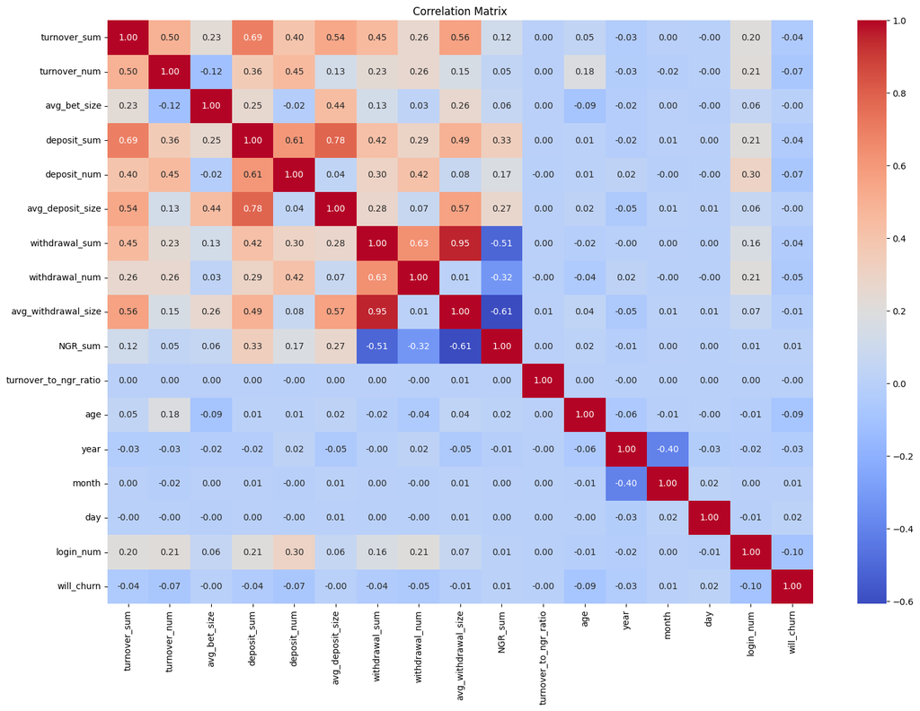

```python
turnover_features = ['turnover_sum', 'turnover_num', 'avg_bet_size']
deposit_features = ['deposit_sum', 'deposit_num', 'avg_deposit_size']
withdrawal_features = ['withdrawal_sum', 'withdrawal_num', 'avg_withdrawal_size']
ngr_features = ['NGR_sum','turnover_to_ngr_ratio']
other_features = ['age', 'year', 'month', 'day', 'login_num']
target = ['will_churn']

non_historical_features= turnover_features + deposit_features + withdrawal_features + ngr_features + other_features + target
df['will_churn'] = df['will_churn'].astype(int)  # Convert to integer (0 or 1)

# Plot the correlation matrix
correlation_matrix = df[non_historical_features].corr()
plt.figure(figsize=(18, 12))
sns.heatmap(correlation_matrix, annot=True, fmt=".2f", cmap='coolwarm')
plt.title('Correlation Matrix')
plt.show()

# The correlation between the target variable and the features are small.
# We could remove average_withdrawal size from our feature list given the high corr with withdrawal_sum.
```

```python
df['will_churn']
```

```
date
2020-07-12    0
2020-07-28    0
2020-08-03    0
2020-08-07    0
2020-08-13    0
             ..
2021-12-02    0
2021-12-11    0
2021-12-21    1
2023-01-21    0
2023-01-24    1
Name: will_churn, Length: 404409, dtype: int64
```

## Model Building

I’ve decided to use a **Random Forest** for my model because of the following:

- **Simplicity** – It’s easy to understand and explain, making it a solid choice for practical use.
- **Handles Weakly Correlated Features Well** – Since my dataset doesn’t have strong feature relationships, Random Forest naturally selects the most important ones.
- **Efficient for Small to Medium Datasets** (100K–500K rows) – It trains faster than boosting methods while still delivering strong performance.

To make sure my model is actually useful and not just guessing based on the majority class, I’m focusing on these **key metrics**:

1. **Confusion Matrix**
- This gives a clear picture of where the model is getting things right and where it’s messing up, especially in terms of false positives (predicting churn when there isn’t) and false negatives (missing actual churners).
2. **Precision, Recall, and F1-Score**
- Instead of just looking at overall accuracy (which can be misleading with imbalanced data), I’ll break down precision, recall, and F1-score for both churners and non-churners. This helps ensure the model isn’t just favoring the majority class.
3. **Precision-Recall Curve & AUC**
- Since we have way more non-churners than churners, PR AUC is a better measure than standard accuracy or ROC AUC.

I will test this against a **simple baseline** where it always **predict that 'will_churn'=False.**

```python
# Create training and testing set.
split_date = '2022-11-12'
train_data = df[df.index < split_date]
test_data = df[df.index >= split_date]
print(f"Train set%: {len(train_data) / len(df) * 100:.2f}%")
print(f"Train set%: {len(test_data) / len(df) * 100:.2f}%")
```

```
Train set%: 69.99%
Train set%: 30.01%
```

```python
print("Training set:")
print(train_data['will_churn'].value_counts(normalize=True))

print("\nTesting set:")
print(test_data['will_churn'].value_counts(normalize=True))
```

```
Training set:
0    0.939584
1    0.060416
Name: will_churn, dtype: float64

Testing set:
0    0.95705
1    0.04295
Name: will_churn, dtype: float64
```

```python
df.columns
```

```
Index(['player_key', 'turnover_sum', 'turnover_num', 'NGR_sum', 'deposit_sum',
       'deposit_num', 'withdrawal_sum', 'withdrawal_num', 'login_num', 'age',
       'days_since_last_bet', 'churned', 'will_churn', 'avg_bet_size',
       'avg_withdrawal_size', 'avg_deposit_size', 'turnover_to_ngr_ratio',
       'rolling_login_num_diff', 'rolling_deposit_num_diff',
       'rolling_withdrawal_num_diff', 'rolling_NGR_diff', 'year', 'month',
       'day'],
      dtype='object')
```

```python
from sklearn.ensemble import RandomForestClassifier
excluded_cols = ['player_key', 'will_churn', 'churned']

X_train = train_data.drop(columns=excluded_cols).values
y_train = train_data['will_churn'].values.astype(bool)

X_test = test_data.drop(columns=excluded_cols).values
y_test = test_data['will_churn'].values.astype(bool)
```

```python
from sklearn.ensemble import RandomForestClassifier
from sklearn.impute import SimpleImputer

# Handle NaN and inf values.
X_train[np.isinf(X_train)] = np.nan
X_test[np.isinf(X_test)] = np.nan
imputer = SimpleImputer(strategy="median")  # Since we have outliers, we use median.
X_train_imputed = imputer.fit_transform(X_train)
X_test_imputed = imputer.transform(X_test)

# Initialize Random Forest with basic parameters
rf_model = RandomForestClassifier(
    n_estimators=400,   # More trees can help stabilize the impact of class imbalance
    max_depth=9,       # Shallower trees generalize better
    min_samples_split=12,  # More data per decision split, helping with generalization
    min_samples_leaf=5,
    class_weight={0: 1, 1: 11}, # forces the model to prioritize churners more
    random_state=42,
    n_jobs=-1
)

# Fit the model
rf_model.fit(X_train_imputed, y_train)
```

```
RandomForestClassifier(class_weight={0: 1, 1: 11}, max_depth=9,
                       min_samples_leaf=5, min_samples_split=12,
                       n_estimators=400, n_jobs=-1, random_state=42)
```

```python
from sklearn.metrics import confusion_matrix, classification_report, average_precision_score

# Make predictions on the test set
y_pred = rf_model.predict(X_test_imputed)
y_pred_proba = rf_model.predict_proba(X_test_imputed)[:, 1]

# 1. Confusion Matrix
cm = confusion_matrix(y_test, y_pred)
print("Confusion Matrix:")
print(cm)

# 2. Precision, Recall, and F1-Score
print("\nClassification Report:")
print(classification_report(y_test, y_pred))

# 3. Precision-Recall AUC
pr_auc = average_precision_score(y_test, y_pred_proba)
print("Precision-Recall AUC: {:.3f}".format(pr_auc))
```

```
Confusion Matrix:
[[96376 19784]
 [ 2250  2963]]

Classification Report:
              precision    recall  f1-score   support

       False       0.98      0.83      0.90    116160
        True       0.13      0.57      0.21      5213

    accuracy                           0.82    121373
   macro avg       0.55      0.70      0.55    121373
weighted avg       0.94      0.82      0.87    121373

Precision-Recall AUC: 0.145
```

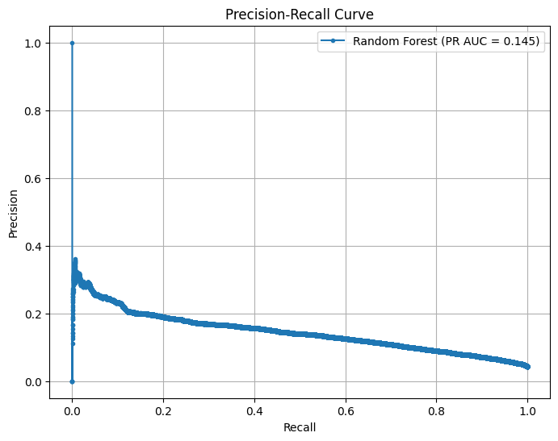

```python
from sklearn.metrics import precision_recall_curve
# Compute precision-recall curve
precision, recall, _ = precision_recall_curve(y_test, y_pred_proba)

# Plot the Precision-Recall Curve
plt.figure(figsize=(8, 6))
plt.plot(recall, precision, marker='.', label=f'Random Forest (PR AUC = {pr_auc:.3f})')
plt.xlabel('Recall')
plt.ylabel('Precision')
plt.title('Precision-Recall Curve')
plt.legend()
plt.grid(True)
plt.show()
```

```python
# Baseline. Always predict 'will_churn' = False.

baseline_preds = np.zeros_like(y_test)
# Evaluate the baseline model
baseline_cm = confusion_matrix(y_test, baseline_preds)
baseline_report = classification_report(y_test, baseline_preds, zero_division=0)

# 1. Confusion Matrix
cm = confusion_matrix(y_test, baseline_preds)
print("Confusion Matrix:")
print(cm)

# 2. Precision, Recall, and F1-Score
print("\nClassification Report:")
print(classification_report(y_test, baseline_preds))
```

```
Confusion Matrix:
[[116160      0]
 [  5213      0]]

Classification Report:
              precision    recall  f1-score   support

       False       0.96      1.00      0.98    116160
        True       0.00      0.00      0.00      5213

    accuracy                           0.96    121373
   macro avg       0.48      0.50      0.49    121373
weighted avg       0.92      0.96      0.94    121373
```

# 📊 Model Evaluation Report

## ✅ Strengths

1. The **only decent thing** about the Random Forest (RF) model is that it has a **moderate recall for churners (57%)**.
   - This is **slightly better than random guessing**, but not much to celebrate.

## ❌ Limitations

1. **Precision is extremely low (0.13)**
   - The model is flagging **way too many false positives**.
   - We don’t want the business **wasting resources on customers who aren’t actually at risk**.
   - **Tuning class weights didn’t really help.**
2. **We’re still missing 43% of actual churners**
   - This could be a **major issue if those are high-value customers**.
   - Catching **just over half of churners isn’t good enough** in a real-world setting.
3. **PR AUC is low (0.145)**
   - The model **isn’t distinguishing churners from non-churners well enough**.
   - **Definitely not production-ready** at this stage.

## 🚀 Recommendations

1. **Try better models for handling class imbalance**
   - **XGBoost** (if we have GPU resources) → Handles class imbalance well with `scale_pos_weight`.
   - **HistGradientBoostingClassifier** (if we need something faster & more memory-efficient).
   - Compare bagging (e.g., Random Forest) with boosting approaches mentioned earlier.
2. **Experiment with different churn windows**
   - Based on my **EDA (Exploratory Data Analysis) plots**, major behavior shifts seem to happen around **day 15**.
   - It might make more sense to **define churn based on this timeframe** rather than an arbitrary cutoff.
3. **Improve Feature Engineering**
   - Our current features might not be fully capturing churn patterns.
   - We should experiment with **time-based features** (e.g., "change in deposit frequency over last 30 days").
4. **Segment the data by player type & evaluate separately**
   - As someone who was a regular live poker player, it makes sense that **high-rollers, professional players, and casual players** have drastically different betting, depositing, and withdrawal behaviors.
   - Instead of treating all players the same, we should run evaluations per segment to improve model performance and even create accompanying CRM retention methods for each segment.